# Experiment 3: What is children’s over-exploration driven by?

Amy Li

10/19/2019

Sections marked (*) indicate that they contain figures and analyses either on, or directly relevant to, the poster!

Load required packages, and specify files to be read.

```r
library(tidyverse)
library(ggthemes)
library(ggplot2)
library(here)
library(BayesFactor)
library(ordinal)

data_sum <- read_csv(here("data_tidy","kb-s3.1-summary.csv"))
data_sum$feedback <- factor(data_sum$feedback, c("partial","full"))
data_sum$group <- as.factor(data_sum$group)
data_sum$correct <- as.factor(data_sum$correct)

data_sum_c <- data_sum %>% filter(group=="child")
data_sum_a <- data_sum %>% filter(group=="adult")
data_sum_ff <- data_sum %>% filter(feedback=="full")
```

# 1 Do children persist in over-exploration even when there is no clear need for information-seeking?

## 1.1 Switching (*)

Let’s first visualize switching behaviour - i.e., choosing an option (monster) that was different from the last option chosen.

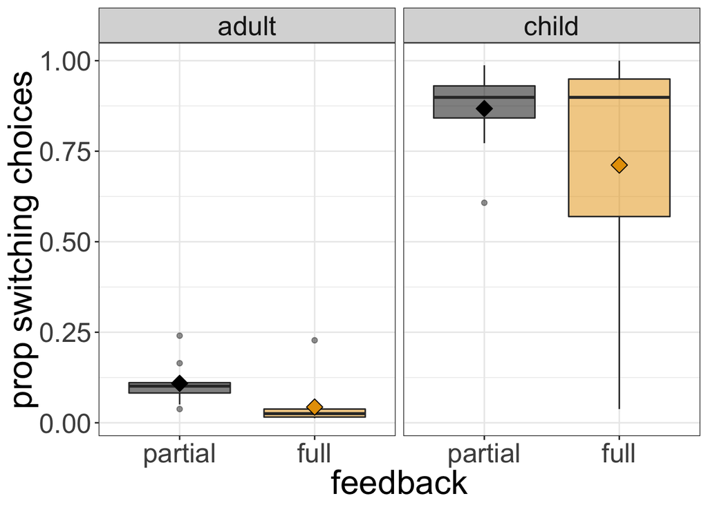

## 1.2 Non-maximizing choices (*)

Let’s visualize the non-maximizing choice proportions - another way we had operationlized exploratory behavior - for adults and children. This was the proportion of choices where participants pick an option other than the one yielding the highest reward chosen so far (e.g., if Tim had chosen the 6-star monster on trial 2, but chose the 2-star monster on trial 3, Tim’s response on trial 3 would be classified as a non-maximizing choice).

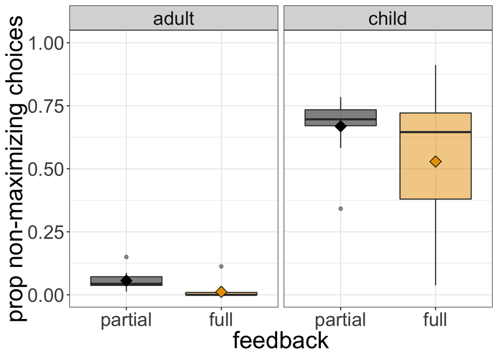

## 1.3 Do children explore at a lower rate in a full-feedback version of the task, compared to when only partial feedback is received? (*)

```r
ttestBF(formula = switch ~ feedback, data = data_sum_c)
```

```
## Bayes factor analysis
## --------------
## [1] Alt., r=0.707 : 0.8220395 ±0%
##
## Against denominator:
##   Null, mu1-mu2 = 0
## ---
## Bayes factor type: BFindepSample, JZS
```

```r
ttestBF(formula = nonMax ~ feedback, data = data_sum_c)
```

```
## Bayes factor analysis
## --------------
## [1] Alt., r=0.707 : 0.9014273 ±0%
##
## Against denominator:
##   Null, mu1-mu2 = 0
## ---
## Bayes factor type: BFindepSample, JZS
```

## 1.4 What affects level of exploration?

We perform a Bayesian ANOVA here examining main effects of feedback type and age group, as well as interaction effects, for each measure of exploration.

```r
anovaSwitch <- anovaBF(switch ~ feedback*group, data = data_sum)
anovaSwitch
```

```
## Bayes factor analysis
## --------------
## [1] group                             : 5.089318e+13 ±0%
## [2] feedback                          : 0.5172468    ±0.02%
## [3] group + feedback                  : 7.95769e+13  ±1.62%
## [4] group + feedback + group:feedback : 3.878769e+13 ±5.63%
##
## Against denominator:
##   Intercept only
## ---
## Bayes factor type: BFlinearModel, JZS
```

```r
anovaNonMax <- anovaBF(nonMax ~ feedback*group, data = data_sum)
anovaNonMax
```

```
## Bayes factor analysis
## --------------
## [1] group                             : 5.786646e+12 ±0%
## [2] feedback                          : 0.5362397    ±0.01%
## [3] group + feedback                  : 9.83494e+12  ±12.89%
## [4] group + feedback + group:feedback : 5.164268e+12 ±9.6%
##
## Against denominator:
##   Intercept only
## ---
## Bayes factor type: BFlinearModel, JZS
```

It seems that for both measures of exploration, a model that contains both main effects (of age group and feedback condition) best predicts one’s level of exploration.

Back to top

# 2 Performance on the posttest recall task: What predicts better recall of choice-reward associations? (*)

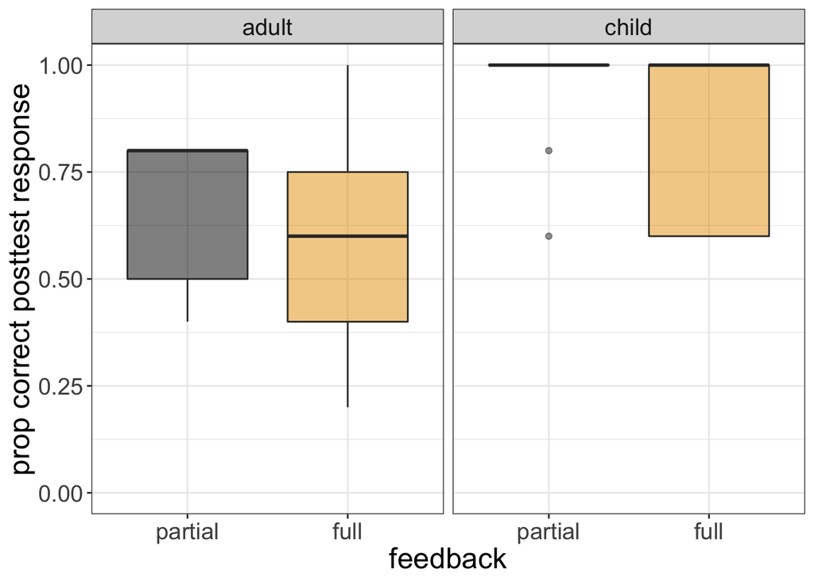

We use cumulative link models to see if age group predicts performance on the posttest.

```r
summary(clm2(correct~feedback*group,data=data_sum))
```

```
## Call:
## clm2(location = correct ~ feedback * group, data = data_sum)
##
## Location coefficients:
##                         Estimate Std. Error z value Pr(>|z|)
## feedbackfull            -0.8524   0.7495    -1.1373 0.25540272
## groupchild               2.9974   0.9895     3.0291 0.00245246
## feedbackfull:groupchild -0.4077   1.2200    -0.3342 0.73824908
##
## No scale coefficients
##
## Threshold coefficients:
##         Estimate Std. Error z value
## 0.2|0.4 -3.7688   1.1440    -3.2944
## 0.4|0.6 -1.3385   0.6493    -2.0615
## 0.6|0.8  0.0252   0.5677     0.0444
## 0.8|1    1.5407   0.6188     2.4898
##
## log-likelihood: -55.34117
## AIC: 124.6823
## Condition number of Hessian: 55.17264
```

In experiment 3, children do better than adults on memory of choice-reward associations across both feedback conditions. Receiving full feedback does not appear to help recall on the posttest.

Does receiving full feedback allow adults to outperform children on the posttest questions?

```r
summary(clm2(correct~group,data=data_sum_ff))
```

```
## Call:
## clm2(location = correct ~ group, data = data_sum_ff)
##
## Location coefficients:
##            Estimate Std. Error z value Pr(>|z|)
## groupchild  2.4040   0.8249     2.9144 0.0035641
##
## No scale coefficients
##
## Threshold coefficients:
##         Estimate Std. Error z value
## 0.2|0.4 -2.6515   1.0395    -2.5507
## 0.4|0.6 -0.7105   0.5636    -1.2605
## 0.6|0.8  1.2157   0.5948     2.0439
## 0.8|1    2.0273   0.6728     3.0132
##
## log-likelihood: -33.4001
## AIC: 76.80021
## Condition number of Hessian: 22.41159
```

No – even when they are receiving information about outcomes on every trial, adults have poorer recall of choice-reward associations on the posttest.

```r
fit1 <- clm2(correct~group + switch + nonMax,data=data_sum)
fit2 <- clm2(correct~switch + nonMax, data=data_sum)
fit3 <- clm2(correct~group, data=data_sum)
```

```r
anova(fit1, fit2)
```

```
## Likelihood ratio tests of cumulative link models
##
## Response: correct
##                           Model Resid. df -2logLik   Test    Df   LR stat.
## 1         switch + nonMax |  |         42 100.5066
## 2 group + switch + nonMax |  |         41 100.4812 1 vs 2     1 0.02544087
##     Pr(Chi)
## 1
## 2 0.8732734
```

```r
anova(fit1, fit3)
```

```
## Likelihood ratio tests of cumulative link models
##
## Response: correct
##                           Model Resid. df -2logLik   Test    Df LR stat.
## 1                   group |  |         43 113.7720
## 2 group + switch + nonMax |  |         41 100.4812 1 vs 2     2 13.29082
##       Pr(Chi)
## 1
## 2 0.001299974
```

Controlling for age group, switching and non-maximizing choices still remain significant predictors of posttest peroformance. On the other hand, when controlling for switching and non-maximizing choices, group is no longer a significant predictor of posttest performance.

Hence, this suggests that it is children’s tendency to explore that explains their better recall of choice-reward associations.

Back to top